# Data Analysis and Visualization

## Abdulrahman Mohammed Alobaidy

### Cohort 9

### Data Analyst Nanodegree Program

#### Email: AbdulrahmanAlobaidy2001@gmail.com

# Dataset Overview

This data set contains information about the **Ford Go** bike-sharing system, the dataset contains data points a little more than 180,000 data points for the month of February of the year 2019.

# Investigation Overview

The aim of this investigation is uncover patterns in the dataset and correlations between the the many variables that may help us understand the users and identify our key demographics that are most likely to benefit from our services.

We see that the bulk of the time spent was in the 5 to 10-minute range, with the distribution continuously decreasing as the time spent using the bike gets longer.

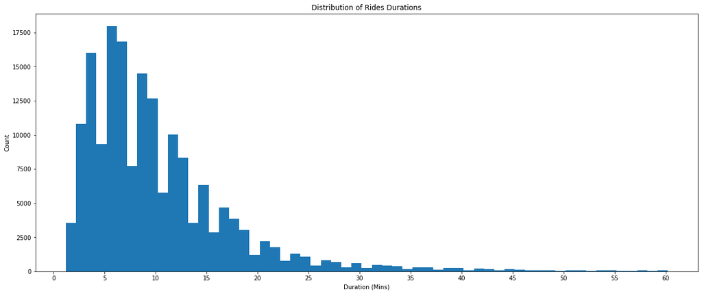

```python
bins = np.arange(df['duration_min'].min(), df['duration_min'].max() + 1, 1)

plt.figure(figsize = (20, 8))

plt.hist(data = df, x = 'duration_min', bins = bins)

ticks = [x for x in range(0, 65, 5)]

plt.xticks(ticks, ticks)

plt.title('Distribution of Rides Durations')
plt.xlabel('Duration (Mins)')
plt.ylabel('Count');
```

From this plot, we notice that the highest usage hour was in the 8 o'clock in the morning as well as the 5 o'clock in the afternoon, which suggests that probably most of the users are using the service to commute to work.

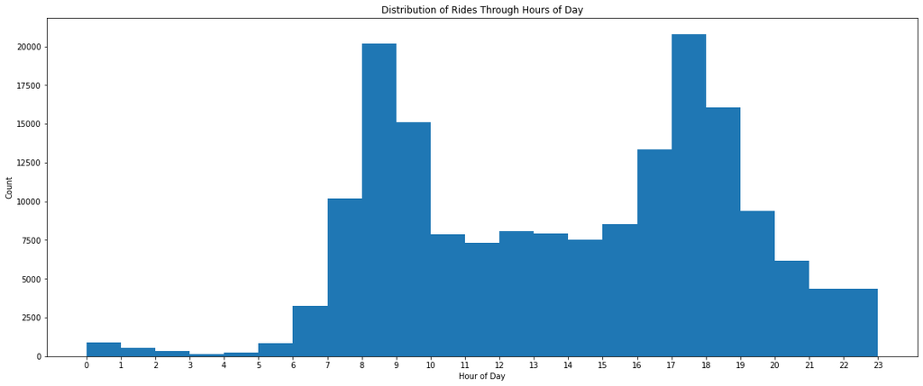

```python
bins = np.arange(0, 24, 1)

plt.figure(figsize = (20, 8))

plt.hist(data = df, x = 'hour_of_day', bins = bins)

ticks = [i for i in range(24)]

plt.title('Distribution of Rides Through Hours of Day')
plt.xlabel('Hour of Day')
plt.ylabel('Count')
plt.xticks(ticks, ticks);
```

We notice that the bulk of our users are in the age range of 20 to 40 years of age.

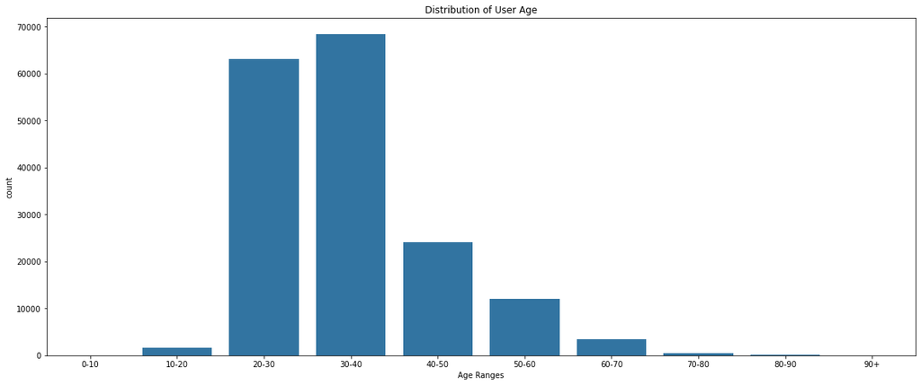

```python
base_color = sb.color_palette()[0]

plt.figure(figsize = (20, 8))

sb.countplot(data = df, x = 'age_range', order = age_ranges_labels, color = base_color)

plt.title('Distribution of User Age')
plt.xlabel('Age Ranges');
```

**91%** of the users are **Subscribers** and **9%** are **Customers**.

Males constitute three quarters of the dataset, while females constitute 23% and 2% for **Others**.

The plot shows that **90%** of the bikes are **not** part of a bike sharing program, while **10%** are.

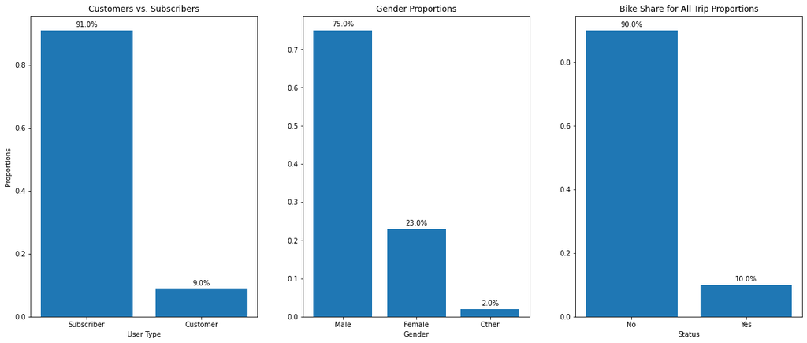

```python
plt.figure(figsize = (20,8))

plt.subplot(1,3,1)

type_count = df['user_type'].value_counts()

type_props = round(type_count / df.shape[0], 2)


plt.bar(np.arange(0, len(type_count)), type_props)


for i in range(len(type_props)):

    plt.text(i, type_props[i] + 0.01, str(type_props[i]*100) + '%', ha = 'center')


plt.title('Customers vs. Subscribers')
plt.xlabel('User Type')
plt.ylabel('Proportions')
plt.xticks(np.arange(0, len(type_count)), type_count.index);



plt.subplot(1,3,2)
gender_count = df['member_gender'].value_counts()

gender_props = round(gender_count / df.shape[0], 2)


plt.bar(np.arange(0, len(gender_count)), gender_props)

for i in range(len(gender_props)):

    plt.text(i, gender_props[i] + 0.01, str(gender_props[i]*100) + '%', ha = 'center')


plt.title('Gender Proportions')
plt.xlabel('Gender')
plt.xticks(np.arange(0, len(gender_count)), gender_count.index);




plt.subplot(1,3,3)
bike_share_count = df['bike_share_for_all_trip'].value_counts()

bike_share_props = round(bike_share_count / df.shape[0], 2)


plt.bar(np.arange(0, len(bike_share_count)), bike_share_props)

for i in range(len(bike_share_props)):

    plt.text(i, bike_share_props[i] + 0.01, str(bike_share_props[i]*100) + '%', ha = 'center')


plt.title('Bike Share for All Trip Proportions')
plt.xlabel('Status')
plt.xticks(np.arange(0, len(bike_share_count)), bike_share_count.index);
```

The following three plots show the 20 most used stations as a trip origin, destinatin, and 20 most popular routes respectively.

The 20 most used start stations make up about **25%** of the total trips count.

The 20 most used end stations make up about **27%** of the total trips count.

The 20 most used routes make up about **3%** of the total trips count.

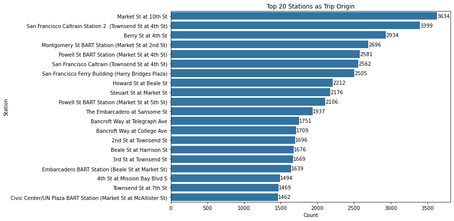

```python
most_used_start_stations = df['start_station_name'].value_counts()[0:20]

base_color = sb.color_palette()[0]

plt.figure(figsize = (10, 7))

sb.barplot(data = df, y = most_used_start_stations.index, x = most_used_start_stations, color = base_color)

for i in range(len(most_used_start_stations)):
    plt.text(most_used_start_stations[i], i, str(most_used_start_stations[i]), va = 'center')

plt.title('Top 20 Stations as Trip Origin')
plt.ylabel('Station')
plt.xlabel('Count');
```

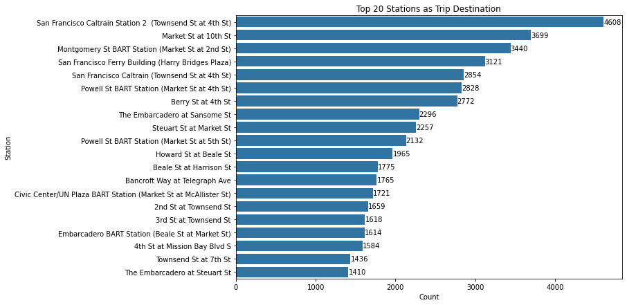

```python
most_used_end_stations = df['end_station_name'].value_counts()[0:20]

base_color = sb.color_palette()[0]

plt.figure(figsize = (10, 7))

sb.barplot(data = df, y = most_used_end_stations.index, x = most_used_end_stations, color = base_color)

for i in range(len(most_used_end_stations)):
    plt.text(most_used_end_stations[i], i, str(most_used_end_stations[i]), va = 'center')

plt.title('Top 20 Stations as Trip Destination')
plt.ylabel('Station')
plt.xlabel('Count');
```

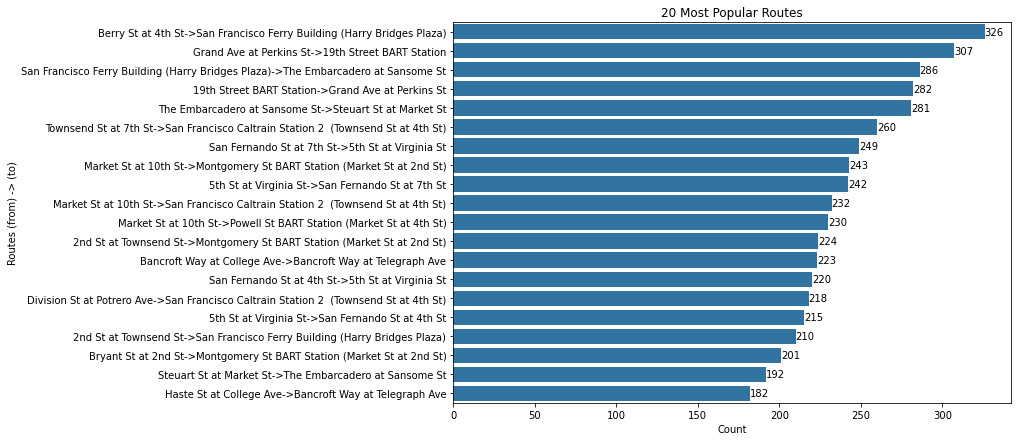

```python
most_used_routes = df['route'].value_counts()[0:20]

base_color = sb.color_palette()[0]

plt.figure(figsize = (10, 7))

sb.barplot(data = df, y = most_used_routes.index, x = most_used_routes, color = base_color)

for i in range(len(most_used_routes)):
    plt.text(most_used_routes[i], i, str(most_used_routes[i]), va = 'center')

plt.title('20 Most Popular Routes')
plt.ylabel('Routes (from) -> (to)')
plt.xlabel('Count');
```

From the following heatmap we notice that most of the data points are concentrated in the duration of 5 to 15 minutes for users within age range of 20 to 40 years old.

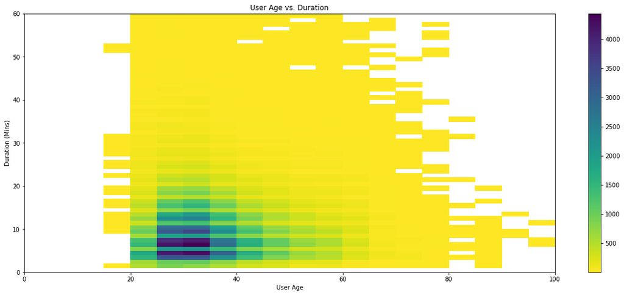

```python
bins_x = np.arange(0, df['user_age'].max() + 5, 5)
bins_y = np.arange(0, df['duration_min'].max() + 1, 1)

plt.figure(figsize = (20, 8))

plt.hist2d(data = df, x = 'user_age', y = 'duration_min', cmin = 0.5, cmap = 'viridis_r', bins = [bins_x, bins_y])

plt.title('User Age vs. Duration')
plt.xlabel('User Age')
plt.ylabel('Duration (Mins)')
plt.colorbar();
```

For the two following box plots, the first one suggest that males have a higher median than females when it comes to user ages, but not by too much, as for the second one, it suggest that females have a higher median than males when it comes to ride duration, again, by not much.

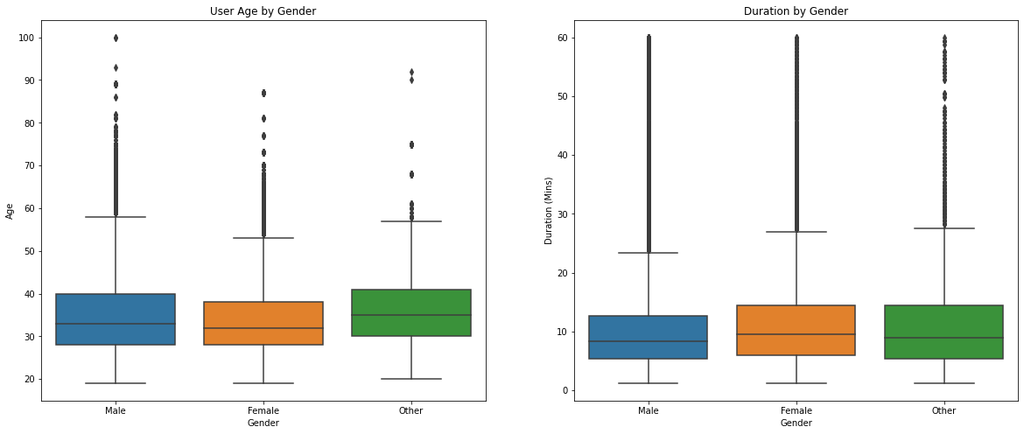

```python
plt.figure(figsize = (20, 8))

plt.subplot(1,2,1)
sb.boxplot(data = df, x = 'member_gender', y = 'user_age')
plt.title('User Age by Gender')
plt.xlabel('Gender')
plt.ylabel('Age')


plt.subplot(1,2,2)
sb.boxplot(data = df, x = 'member_gender', y = 'duration_min')
plt.title('Duration by Gender')
plt.xlabel('Gender')
plt.ylabel('Duration (Mins)');
```

The following box plots show that users of both types, Subscribers and Customers, both have about the same median when it comes to age, but customers have a higher median when it comes to duration.

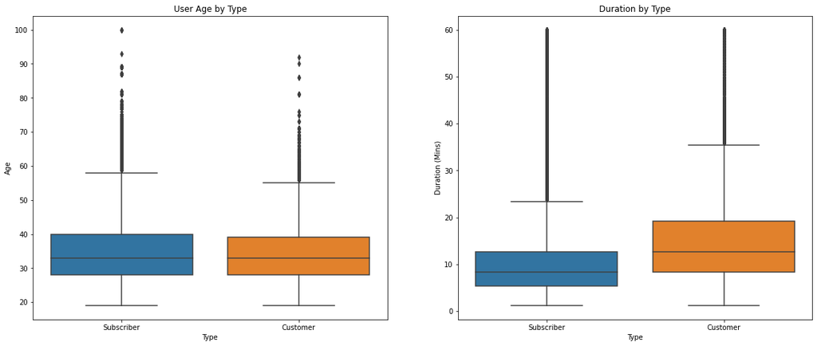

```python
plt.figure(figsize = (20, 8))

plt.subplot(1,2,1)
sb.boxplot(data = df, x = 'user_type', y = 'user_age')
plt.title('User Age by Type')
plt.xlabel('Type')
plt.ylabel('Age')


plt.subplot(1,2,2)
sb.boxplot(data = df, x = 'user_type', y = 'duration_min')
plt.title('Duration by Type')
plt.xlabel('Type')
plt.ylabel('Duration (Mins)');
```

# Resources

All of the code and datasets for this project are included on a [Github Repository](https://github.com/AbdulrahmanAlobaidy/DAND-project-5) dedicated for this project, including this Notebook in its `ipynb` and HTML format as well as any other relevant files.